# STATS506: Final Project

# Introduction

Energy is important for human’s daily life. Making heat is one of the purpose.

Heating your home uses more energy. Currently, we have multiple heating sources for home buildings: Natural gas, electricity, propane and so on. But as the country started to develop the clean energy, the components of market may change. Meanwhile, ways we use energy may change as well. To better trace the change of the market, understanding the market share of each source and the main purpose of energy used become important. It will help the government to understand the movement of energy market.

In this project, we will focus on the component of heating energy market. Exploring the component of the heating energy market and get to know what’s the most frequently used heating energy source in each Census Region.

# Data

We will use the [2012 US Commercial Building Energy Consumption Survey](https://www.eia.gov/consumption/commercial/data/2012/index.php?view=microdata) data to perform the analysis.

- In this analysis, we will use the following variables:
  - REGION (Region)
  - ELHT1,NGHT1,FKHT1,PRHT1,STHT1,HWHT1,WOHT1,COHT1,SOHT1,OTHT1
    - The indicators for each heat sources
    - Modify the indicators for each heat sources by applying the following rule
      - 1: if that source used for main heat (value: 1)
      - 0: if that source not used for main heat or value is missing (value 2 or NA)
  - FINALWT, FINALWT1 - FINALWT197
    - The weights we used for domain analysis
    - sample weight: FINALWT
    - repeat weight: FINALWT1 - FINALWT197
  - The detailed data description is [here](https://www.eia.gov/consumption/commercial/data/2012/xls/2012microdata_codebook.xlsx)
- Reshaping the data so that all the heat sources’ names are in the column `MainHeatSource` and its respectively values are in the column `indicator`

# Methodology

- Average proportion was computed for each Census region and energy source and compared visually. All estimates are given with 95% confidence intervals computed using the balance repeated replicate weights as described in the [documentation](https://www.eia.gov/consumption/commercial/data/2012/pdf/user_guide_public_use_aug2016.pdf)
- performing the one-way anova analysis to determine whether the proportions of each energy source are the same in each census region.
  - We will use `svyglm` function instead of `lm` since `svyglm` will compute using replicate weights.
- The code we used to generate results are stored in [github](https://github.com/zhaodyleo/STATS_506_FinalProject/blob/master/Rscript.R)

# Results

## expected proportion for each source with 95% confidence intervals

### table

```r
cap_tab1 = paste(
 "**Table 1.** *Proportion of each energy source used in each Region.*",
 "Numbers in parantheses represent 95% confidence intervals."
)
rownames(svyresult) = c()
svyresult$MainHeatSource = svyresult$MainHeatSource %>%
  map(Energy_map) %>% unlist()
svyresult  %>%
  transmute(
    Region = REGION ,
    MainHeatSource = MainHeatSource ,
    `Proportion(%)` = sprintf('<div>%4.2f</div> <div>(%4.2f, %4.2f)</div>',
                     indicator * 100, lwr * 100, upr * 100)
  ) %>%
  knitr::kable(
    format = 'html',
    escape = FALSE,
    align = 'llccc',
    cap = cap_tab1
  ) %>%
  kableExtra::kable_styling("striped", full_width = TRUE)
```

**Table 1.** *Proportion of each energy source used in each Region.* Numbers in parantheses represent 95% confidence intervals.

| Region | MainHeatSource | Proportion(%) |
| --- | --- | --- |
| Midwest | Coal | 0.18 (0.13, 0.24) |
| Northeast | Coal | 0.00 (0.00, 0.00) |
| South | Coal | 0.00 (0.00, 0.00) |
| West | Coal | 0.11 (0.09, 0.14) |
| Midwest | Electricity | 15.56 (14.87, 16.25) |
| Northeast | Electricity | 17.18 (16.53, 17.84) |
| South | Electricity | 46.43 (45.53, 47.34) |
| West | Electricity | 35.11 (34.01, 36.21) |
| Midwest | Fuel oil | 2.11 (2.02, 2.21) |
| Northeast | Fuel oil | 17.44 (16.42, 18.47) |
| South | Fuel oil | 1.42 (1.32, 1.52) |
| West | Fuel oil | 0.54 (0.46, 0.61) |
| Midwest | District hot water | 0.03 (0.03, 0.04) |
| Northeast | District hot water | 0.22 (0.17, 0.27) |
| South | District hot water | 0.43 (0.38, 0.49) |
| West | District hot water | 0.40 (0.36, 0.44) |
| Midwest | Natural gas | 62.03 (61.37, 62.69) |
| Northeast | Natural gas | 44.81 (43.50, 46.13) |
| South | Natural gas | 28.81 (28.15, 29.47) |
| West | Natural gas | 43.13 (42.01, 44.24) |
| Midwest | Others | 0.41 (0.35, 0.47) |
| Northeast | Others | 0.58 (0.49, 0.67) |
| South | Others | 0.28 (0.23, 0.33) |
| West | Others | 0.73 (0.53, 0.92) |
| Midwest | Propane | 6.82 (6.51, 7.12) |
| Northeast | Propane | 5.74 (5.41, 6.06) |
| South | Propane | 4.09 (3.89, 4.29) |
| West | Propane | 3.03 (2.72, 3.34) |
| Midwest | Solar | 0.00 (0.00, 0.00) |
| Northeast | Solar | 0.00 (0.00, 0.00) |
| South | Solar | 0.00 (0.00, 0.00) |
| West | Solar | 0.00 (0.00, 0.00) |
| Midwest | District steam | 0.49 (0.45, 0.53) |
| Northeast | District steam | 1.70 (1.49, 1.91) |
| South | District steam | 0.37 (0.34, 0.41) |
| West | District steam | 0.16 (0.14, 0.18) |
| Midwest | Wood | 0.97 (0.88, 1.07) |
| Northeast | Wood | 2.54 (2.08, 3.00) |
| South | Wood | 0.14 (0.11, 0.17) |
| West | Wood | 0.20 (0.15, 0.25) |

### figures

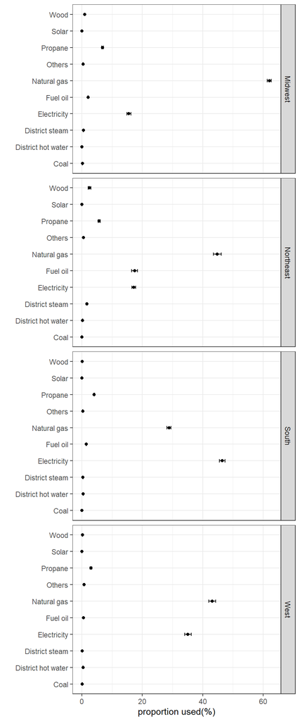

**Figure 1** *Proportion of each energy source used in each Region.*

```r
cap1a1 = paste(
  "**Figure 1** *Proportion of each energy source used in each Region.*"
)
svyresult  %>%
  transmute(
    Region = REGION ,
    MainHeatSource = MainHeatSource,
    indicator = indicator * 100,
    lwr = lwr * 100,
    upr = upr * 100
  ) %>%
  ggplot(
    aes(x = MainHeatSource, y = indicator)) +
  geom_point( position = position_dodge(.5) ) +
  geom_errorbar(
    aes(ymin = lwr, ymax = upr),
    position = position_dodge(.5), width = 0.2
  ) +
  facet_grid(Region~.) +
  coord_flip() +
  theme_bw() +
  scale_color_manual(values = c('darkblue', 'darkred')) +
  ylab('proportion used(%)') +
  xlab('')
```

### Testing for the significance output

```r
summary_report = summary(test_output)
report = summary_report$coefficients[,c(1,4)]
colnames(report) = c("Estimation", "Significant?")
report[,2] = report[,2] < 0.05
report %>%
   knitr::kable(
    format = 'html',
    escape = FALSE,
    align = 'llccc',
    cap = "**Table2** *The signicance test by using the linear model(Set up Natural Gas as reference level)*"
  )%>%
  kableExtra::kable_styling("striped", full_width = TRUE)
```

**Table2** *The signicance test by using the linear model(Set up Natural Gas as reference level)*

|  | Estimation | Significant? |
| --- | --- | --- |
| (Intercept) | 0.6202869 | 1 |
| REGIONNortheast | -0.1721639 | 1 |
| REGIONSouth | -0.3321719 | 1 |
| REGIONWest | -0.1890226 | 1 |
| MainHeatSourceCoal:REGIONMidwest | -0.6184538 | 1 |
| MainHeatSourceDistrict hot water:REGIONMidwest | -0.6199495 | 1 |
| MainHeatSourceDistrict steam:REGIONMidwest | -0.6153863 | 1 |
| MainHeatSourceElectricity:REGIONMidwest | -0.4647180 | 1 |
| MainHeatSourceFuel oil:REGIONMidwest | -0.5991591 | 1 |
| MainHeatSourceOthers:REGIONMidwest | -0.6161963 | 1 |
| MainHeatSourcePropane:REGIONMidwest | -0.5521062 | 1 |
| MainHeatSourceSolar:REGIONMidwest | -0.6202869 | 1 |
| MainHeatSourceWood:REGIONMidwest | -0.6105537 | 1 |
| MainHeatSourceCoal:REGIONNortheast | -0.4481230 | 1 |
| MainHeatSourceDistrict hot water:REGIONNortheast | -0.4459223 | 1 |
| MainHeatSourceDistrict steam:REGIONNortheast | -0.4311497 | 1 |
| MainHeatSourceElectricity:REGIONNortheast | -0.2762784 | 1 |
| MainHeatSourceFuel oil:REGIONNortheast | -0.2736831 | 1 |
| MainHeatSourceOthers:REGIONNortheast | -0.4423220 | 1 |
| MainHeatSourcePropane:REGIONNortheast | -0.3907703 | 1 |
| MainHeatSourceSolar:REGIONNortheast | -0.4481230 | 1 |
| MainHeatSourceWood:REGIONNortheast | -0.4227090 | 1 |
| MainHeatSourceCoal:REGIONSouth | -0.2881150 | 1 |
| MainHeatSourceDistrict hot water:REGIONSouth | -0.2837822 | 1 |
| MainHeatSourceDistrict steam:REGIONSouth | -0.2843786 | 1 |
| MainHeatSourceElectricity:REGIONSouth | 0.1762247 | 1 |
| MainHeatSourceFuel oil:REGIONSouth | -0.2739052 | 1 |
| MainHeatSourceOthers:REGIONSouth | -0.2853308 | 1 |
| MainHeatSourcePropane:REGIONSouth | -0.2472136 | 1 |
| MainHeatSourceSolar:REGIONSouth | -0.2881150 | 1 |
| MainHeatSourceWood:REGIONSouth | -0.2866932 | 1 |
| MainHeatSourceCoal:REGIONWest | -0.4301250 | 1 |
| MainHeatSourceDistrict hot water:REGIONWest | -0.4272622 | 1 |
| MainHeatSourceDistrict steam:REGIONWest | -0.4296390 | 1 |
| MainHeatSourceElectricity:REGIONWest | -0.0801681 | 1 |
| MainHeatSourceFuel oil:REGIONWest | -0.4258853 | 1 |
| MainHeatSourceOthers:REGIONWest | -0.4239895 | 1 |
| MainHeatSourcePropane:REGIONWest | -0.4010049 | 1 |
| MainHeatSourceSolar:REGIONWest | -0.4312643 | 1 |
| MainHeatSourceWood:REGIONWest | -0.4292580 | 1 |

# Conclusion

From the results section, we found out the `natural gas` is the most used source of main heat energy.And the results are significant. But South Census region didn’t follow that pattern. Instead of using the natural gas, the South census region’s housing used more electricity for the main heating purpose.

We can directly to find out the component of heating energy market in 2012 and understanding the market sharing of each source in current market.

However, the data we used are energy usage for the commercial buildings. Thus, we can’t make any inferences about the individuals situation unless we can make some association between the commercials and individuals.